# Department of Health — Office of the Secretary

The FY 2027 proposed budget in context, FY 2018–2027

September 2026

← All agencies

# Overview

This document tracks the budget of the **Department of Health – Office of the Secretary (DOH-OSEC)** across ten fiscal years, FY 2018 to FY 2027 — with **FY 2027 the Executive’s proposal (NEP)**, not yet enacted — following each peso from proposal (NEP) to enactment (GAA) to release (allotment), commitment (obligation), and final cash payment (disbursement).

It is the long-form companion to the DOH-OSEC briefing deck. Where the deck fits each point on a slide, this version keeps the full argument and adds reference tables — most sortable, searchable, and exportable — so a reader can interrogate the figures directly. Every table can be copied or downloaded from its toolbar.

Two forces shape DOH-OSEC’s budget. The first is **Congress**: DOH has its budget enlarged by the legislature in every single year of this period, cumulatively by more than ₱210B, and those additions are heavily concentrated in a handful of flagship lines. The second is **absorption**, and specifically a capital-outlay bottleneck — the agency reliably spends its salaries and operating money but struggles to disburse its infrastructure budget, year after year. Most of what follows examines how those two forces interact: money is appropriated faster than the agency’s procurement and construction pipeline can spend it.

# 1 Executive summary

**The FY 2027 proposal (NEP) is ₱264B for DOH-OSEC** — up about ₱10B (+4%) on the FY 2026 proposal, and the largest DOH proposal yet: a *rising*, not shrinking, proposal. But it again sits far below what Congress enacts — the FY 2026 GAA was ₱298B, ₱44B above that year’s proposal. Read against DOH’s history of double-digit-billion augmentation, the FY 2027 NEP is best treated as a floor Congress will build on, not a ceiling.

**Congress augments DOH every year.** The enacted GAA has exceeded the Executive’s NEP in every year of the period — by as little as ₱2B (2018) and as much as ₱44B (2026). Cumulatively, Congress has added about ₱210B on top of Executive proposals over 2018–2026. These additions are **highly concentrated**: MAIFIP alone absorbed ₱97B of cumulative plus-ups and the Health Facilities Enhancement Program (HFEP) another ₱56B — together over 70% of all Congressional augmentation to DOH-OSEC since 2018.

The **portfolio is rebalancing toward MOOE**: the MOOE share of the GAA rose from 39% in 2018 to 53% in 2026, while the Capital Outlay share fell from 29% to 13%. Congressional augmentation is overwhelmingly MOOE-bound (about ₱125B of the ₱210B cumulative plus-up). And **hospital operations dominate** the functional composition and are growing fastest in absolute terms; the **2025 PREXC reorganization** split the public-health side into a policy/strategy program (`3501`) and a local-health-system-support program (`3502`).

> The recurring tension: Congress routes its largest additions into MOOE and into capital-heavy flagships like HFEP, but the agency’s binding constraint is its ability to *disburse* — especially on infrastructure. Appropriating more does not, on this record, translate one-for-one into spending.

# 2 A note on the data

**Period.** FY 2018 through FY 2027 for NEP and FY 2018 through FY 2026 for GAA — **FY 2027 is the NEP (the Executive’s proposal) only**, not yet debated or enacted and with no execution data, so wherever a chart or table shows FY 2027 the figure is *proposed*. Execution data — Adjusted Appropriations, Adjusted Allotments, Obligations, Disbursements — is available at the P/A/P level for every year FY 2018–2025; FY 2026 reflects the proposed/enacted budget only.

**Scope.** **Current New Appropriations only** — excludes Continuing Appropriations, Automatic Appropriations, and transfers from Special Purpose Funds and Unprogrammed Appropriations. These figures therefore understate the DOH’s full spending envelope. All amounts are nominal pesos.

**2025 PREXC re-coding.** DOH renumbered its program codes in 2025. Where the same P/A/P appears under both an old and a new UACS code — `3201`→`3601` (hospitals), `3301`→`3701` (regulation), `3401`→`3801` (patient assistance) — the two are treated as the same line. The public-health programs `3101`–`3105` were reorganized into `3501` and `3502`; see the reorganization section.

**Two P/A/P renames consolidated.** “Assistance to Indigent Patients…” → **MAIFIP**, and “HRH Deployment” (`3102`) → **NHWSS** (re-coded and renamed in 2022). Both are reported as single continuous lines throughout.

**Absorptive-capacity denominator.** Unless noted, ratios use **Adjusted Allotments** — the closest proxy for what the agency was actually cleared to spend. The three ratios are **O/A** (Obligations ÷ Allotment), **D/O** (Disbursements ÷ Obligations), and **D/A** (Disbursements ÷ Allotment).

# 3 The aggregate budget

## 3.1 The budget keeps growing

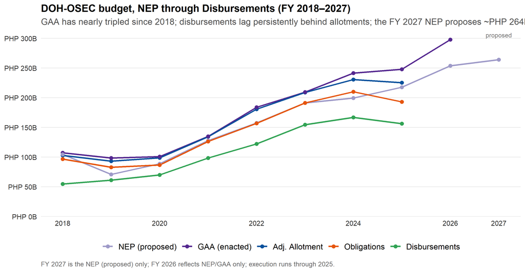

```r
evo <- totals_by_year %>%
  filter(metric %in% c("NEP","GAA","AdjAllot","Obligations","Disbursements")) %>%
  mutate(metric = factor(metric, levels = c("NEP","GAA","AdjAllot","Obligations","Disbursements"),
                         labels = c("NEP (proposed)","GAA (enacted)","Adj. Allotment","Obligations","Disbursements")))

ggplot(evo, aes(year, total, color = metric, group = metric)) +
  geom_line(linewidth = 1.0) + geom_point(size = 2) +
  scale_color_manual(values = exec_pal) +
  scale_y_continuous(labels = php_b_axis, breaks = pretty_breaks(6),
                     limits = c(0, NA), expand = expansion(mult = c(0, .05))) +
  scale_x_continuous(breaks = c(seq(2018, 2026, 2), 2027)) +
  annotate("text", x = 2027, y = Inf, label = "proposed", vjust = 1.4, size = 3, color = "grey45") +
  labs(title = "DOH-OSEC budget, NEP through Disbursements (FY 2018–2027)",
       subtitle = "GAA has nearly tripled since 2018; disbursements lag persistently behind allotments; the FY 2027 NEP proposes ~PHP 264B",
       x = NULL, y = NULL, caption = "FY 2027 is the NEP (proposed) only; FY 2026 reflects NEP/GAA only; execution runs through 2025.") +
  theme_doh() + guides(color = guide_legend(nrow = 1))
```

Two features stand out and organize the rest of this report. First, the **NEP and GAA lines separate visibly in most years** — the enacted budget sits above the Executive’s proposal, the signature of an agency Congress consistently augments (the next sections quantify it). Second, the **disbursement line trails the allotment line by a wide and persistent margin**: DOH releases money it does not fully pay out within the year. The table gives the underlying figures.

```r
tbl_evo <- totals_by_year %>%
  filter(metric %in% c("NEP","GAA","AdjAllot","Obligations","Disbursements")) %>%
  mutate(value = total/1e9) %>% select(year, metric, value) %>%
  pivot_wider(names_from = year, values_from = value) %>%
  mutate(metric = factor(metric, levels = c("NEP","GAA","AdjAllot","Obligations","Disbursements"),
                         labels = c("NEP","GAA","Adj. Allotment","Obligations","Disbursements"))) %>%
  arrange(metric) %>% rename(`PHP B` = metric)
kbl_clean(tbl_evo, font = 13, digits = 1, format.args = list(big.mark = ","), na = "")
```

| PHP B | 2018 | 2019 | 2020 | 2021 | 2022 | 2023 | 2024 | 2025 | 2026 | 2027 |
| --- | --- | --- | --- | --- | --- | --- | --- | --- | --- | --- |
| NEP | 104.7 | 71.0 | 88.7 | 127.8 | 157.5 | 191.2 | 199.5 | 217.8 | 253.8 | 264 |
| GAA | 107.2 | 98.6 | 101.0 | 134.9 | 183.9 | 209.6 | 241.6 | 247.9 | 297.9 |  |
| Adj. Allotment | 102.9 | 93.1 | 98.7 | 134.5 | 180.6 | 208.8 | 230.5 | 225.3 |  |  |
| Obligations | 96.7 | 82.9 | 86.7 | 126.3 | 156.9 | 191.4 | 209.9 | 192.9 |  |  |
| Disbursements | 54.8 | 61.2 | 70.0 | 98.4 | 122.4 | 154.6 | 167.0 | 156.5 |  |  |

## 3.2 Year-on-year growth, and the annual augmentation

The budget contracted in 2019 — a re-enactment year following a budget impasse — and grew every year after. The table pairs each year’s GAA growth with the size of the Congressional add-on (GAA minus NEP), the recurring feature of the DOH budget.

```r
wide_yr <- totals_by_year %>% pivot_wider(names_from = metric, values_from = total)
growth <- wide_yr %>% arrange(year) %>%
  transmute(year,
            `GAA (B)` = round(GAA/1e9,1),
            `Growth %` = scales::percent(GAA/lag(GAA) - 1, accuracy = 0.1),
            `NEP (B)` = round(NEP/1e9,1),
            `Augmentation GAA−NEP (B)` = round((GAA-NEP)/1e9,1))
kbl_clean(growth, font = 13, align = "rrrrr", na = "")
```

| year | GAA (B) | Growth % | NEP (B) | Augmentation GAA−NEP (B) |
| --- | --- | --- | --- | --- |
| 2018 | 107.2 |  | 104.7 | 2.5 |
| 2019 | 98.6 | -8.1% | 71.0 | 27.5 |
| 2020 | 101.0 | 2.5% | 88.7 | 12.3 |
| 2021 | 134.9 | 33.6% | 127.8 | 7.2 |
| 2022 | 183.9 | 36.3% | 157.5 | 26.3 |
| 2023 | 209.6 | 14.0% | 191.2 | 18.4 |
| 2024 | 241.6 | 15.3% | 199.5 | 42.1 |
| 2025 | 247.9 | 2.6% | 217.8 | 30.2 |
| 2026 | 297.9 | 20.1% | 253.8 | 44.0 |
| 2027 |  |  | 264.0 |  |

The augmentation column is positive in every year — the defining characteristic of the DOH-OSEC budget.

# 4 The 2025 PREXC reorganization

A structural caveat that shapes several charts below. In 2025 DOH renumbered its program codes. Most changes were **simple renumbering** with unchanged scope — `3201`→`3601` (Hospital Operations), `3301`→`3701` (Regulation), `3401`→`3801` (Social Health Protection) — and are transparently consolidated here. The substantive change was a **split**: the old five public-health programs (`3101`–`3105`, covering policy, systems, public health, epidemiology, and emergencies) were collapsed into two new programs along a *policy/strategy versus local implementation* dividing line.

```r
reorg <- tibble::tribble(
  ~`P/A/P`,                                            ~`Old (pre-2025)`,                    ~`New (2025+)`,
  "Health Sector Policy and Plan Development",         "3101 Health Policy and Standards",   "3501 Policy & Systems Strengthening",
  "Pharmaceutical Management",                         "3102 Health Systems Strengthening",  "3501 Policy & Systems Strengthening",
  "Health Promotion",                                  "3102 Health Systems Strengthening",  "3501 Policy & Systems Strengthening",
  "Epidemiology and Surveillance",                     "3104 Epidemiology and Surveillance", "3501 Policy & Systems Strengthening",
  "Quick Response Fund",                               "3105 Health Emergency Management",   "3501 Policy & Systems Strengthening",
  "Health Facilities Enhancement Program (HFEP)",      "3102 Health Systems Strengthening",  "3502 Local Health System Support",
  "National Health Workforce Support System (NHWSS)",  "3102 Health Systems Strengthening",  "3502 Local Health System Support",
  "Nationally-procured Commodities (5 new lines)",     "(part of 3103 programs)",            "3502 Local Health System Support"
)
kbl_clean(reorg, font = 13, align = "lll", na = "")
```

| P/A/P | Old (pre-2025) | New (2025+) |
| --- | --- | --- |
| Health Sector Policy and Plan Development | 3101 Health Policy and Standards | 3501 Policy & Systems Strengthening |
| Pharmaceutical Management | 3102 Health Systems Strengthening | 3501 Policy & Systems Strengthening |
| Health Promotion | 3102 Health Systems Strengthening | 3501 Policy & Systems Strengthening |
| Epidemiology and Surveillance | 3104 Epidemiology and Surveillance | 3501 Policy & Systems Strengthening |
| Quick Response Fund | 3105 Health Emergency Management | 3501 Policy & Systems Strengthening |
| Health Facilities Enhancement Program (HFEP) | 3102 Health Systems Strengthening | 3502 Local Health System Support |
| National Health Workforce Support System (NHWSS) | 3102 Health Systems Strengthening | 3502 Local Health System Support |
| Nationally-procured Commodities (5 new lines) | (part of 3103 programs) | 3502 Local Health System Support |

The practical consequence: several public-health lines that existed under the old codes **disappear in 2025** and reappear as new-coded lines, which is why some of the low-absorber trajectories later in this report stop in 2024. Throughout, old and new codes are rolled into one functional bucket so the aggregate trends remain continuous.

# 5 Where the money goes

## 5.1 By functional category

Grouping P/A/Ps into six functional categories shows what kind of agency DOH-OSEC is. The chart shows the enacted budget by category; the tables give pesos and shares.

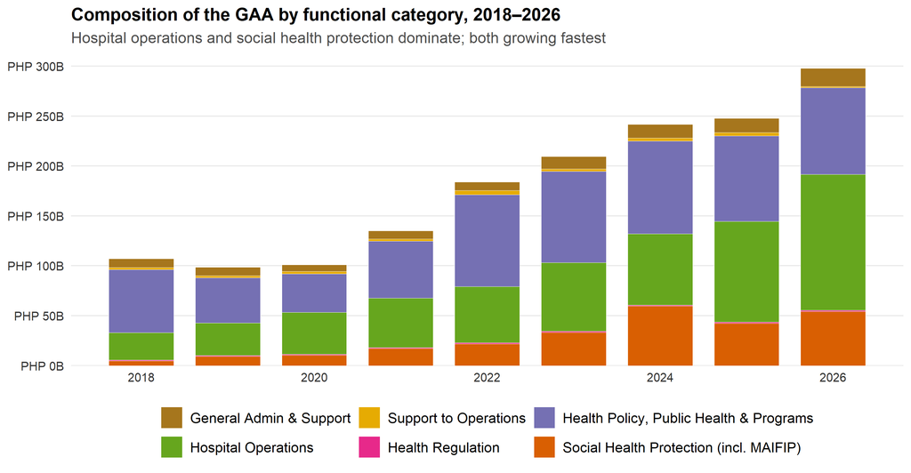

```r
comp <- df_long %>%
  filter(metric == "GAA", year <= 2026, !is.na(amount)) %>%
  group_by(year, category) %>% summarise(amount = sum(amount, na.rm = TRUE), .groups = "drop") %>%
  mutate(category = factor(category, levels = names(cat_pal)))

ggplot(comp, aes(year, amount, fill = category)) +
  geom_col(width = 0.75, color = "white", linewidth = 0.2) +
  scale_fill_manual(values = cat_pal) +
  scale_y_continuous(labels = php_b_axis, breaks = pretty_breaks(6),
                     limits = c(0, NA), expand = expansion(mult = c(0, .05))) +
  scale_x_continuous(breaks = seq(2018, 2026, 2)) +
  labs(title = "Composition of the GAA by functional category, 2018–2026",
       subtitle = "Hospital operations and social health protection dominate; both growing fastest",
       x = NULL, y = NULL) +
  theme_doh() + guides(fill = guide_legend(nrow = 2, byrow = TRUE))
```

**Hospital Operations** is the largest and fastest-growing block in absolute terms — DOH-OSEC runs the country’s regional and specialty hospitals directly, and that operational footprint expands every year. **Social Health Protection**, which houses MAIFIP, is the next major growth story and the most Congress-driven. The public-health-and-programs category is large but structurally fragmented, which is what the 2025 reorganization tried to address.

```r
comp_tbl <- comp %>% group_by(year) %>% mutate(share = amount/sum(amount)) %>% ungroup()
comp_amt <- comp_tbl %>% mutate(amount = round(amount/1e9,1)) %>%
  select(category, year, amount) %>% pivot_wider(names_from = year, values_from = amount)
kbl_clean(comp_amt %>% rename(`Category (PHP B)` = category),
          font = 12, digits = 1, format.args = list(big.mark=","), na = "")
```

| Category (PHP B) | 2018 | 2019 | 2020 | 2021 | 2022 | 2023 | 2024 | 2025 | 2026 |
| --- | --- | --- | --- | --- | --- | --- | --- | --- | --- |
| General Admin & Support | 9.0 | 8.5 | 6.7 | 8.1 | 8.4 | 12.7 | 13.5 | 14.5 | 18.2 |
| Health Policy, Public Health & Programs | 63.0 | 45.3 | 38.5 | 57.4 | 92.0 | 91.4 | 92.7 | 85.5 | 87.0 |
| Health Regulation | 0.8 | 0.8 | 0.9 | 1.1 | 1.0 | 1.1 | 1.1 | 1.3 | 1.4 |
| Hospital Operations | 27.5 | 32.5 | 42.0 | 49.3 | 56.4 | 68.6 | 71.5 | 100.8 | 136.0 |
| Social Health Protection (incl. MAIFIP) | 4.9 | 9.4 | 10.5 | 17.1 | 21.9 | 33.4 | 59.6 | 42.4 | 54.1 |
| Support to Operations | 2.2 | 2.0 | 2.4 | 1.9 | 4.2 | 2.3 | 3.2 | 3.3 | 1.1 |

```r
comp_pct <- comp_tbl %>% mutate(share = round(share*100,1)) %>%
  select(category, year, share) %>% pivot_wider(names_from = year, values_from = share)
```

Share of each year’s total budget:

```r
kbl_clean(comp_pct %>% rename(`Category (% of GAA)` = category), font = 12, digits = 1, na = "")
```

| Category (% of GAA) | 2018 | 2019 | 2020 | 2021 | 2022 | 2023 | 2024 | 2025 | 2026 |
| --- | --- | --- | --- | --- | --- | --- | --- | --- | --- |
| General Admin & Support | 8.4 | 8.6 | 6.6 | 6.0 | 4.6 | 6.1 | 5.6 | 5.9 | 6.1 |
| Health Policy, Public Health & Programs | 58.7 | 46.0 | 38.1 | 42.5 | 50.1 | 43.6 | 38.4 | 34.5 | 29.2 |
| Health Regulation | 0.7 | 0.8 | 0.9 | 0.8 | 0.5 | 0.5 | 0.4 | 0.5 | 0.5 |
| Hospital Operations | 25.7 | 33.0 | 41.6 | 36.5 | 30.7 | 32.7 | 29.6 | 40.7 | 45.7 |
| Social Health Protection (incl. MAIFIP) | 4.5 | 9.5 | 10.4 | 12.7 | 11.9 | 15.9 | 24.7 | 17.1 | 18.2 |
| Support to Operations | 2.0 | 2.1 | 2.4 | 1.4 | 2.3 | 1.1 | 1.3 | 1.3 | 0.4 |

## 5.2 By expense class

The same budget by what the money buys. The defining DOH-OSEC trend is a steady **shift from Capital Outlay toward MOOE**.

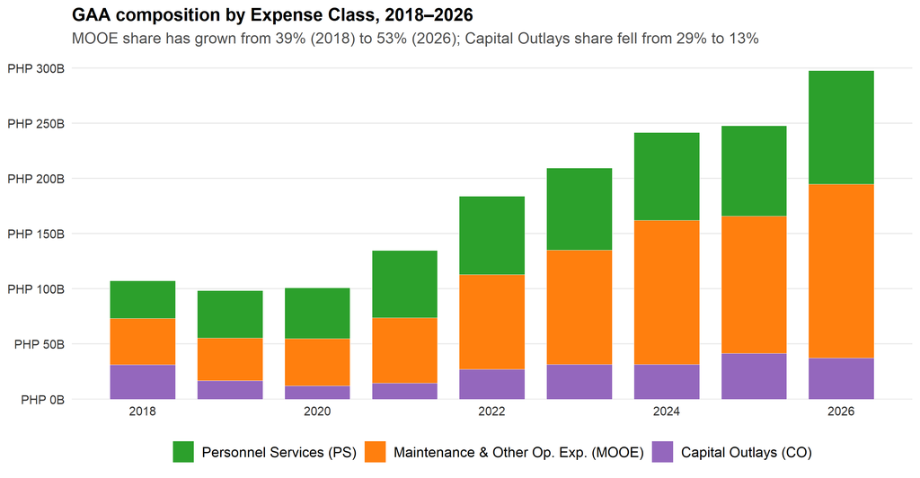

```r
ec_levels <- c("Personnel Services (PS)","Maintenance & Other Op. Exp. (MOOE)","Capital Outlays (CO)")
comp_ec <- df_long_all %>%
  filter(metric == "GAA", year <= 2026, expense_class %in% c("1PS","2MOOE","6CO")) %>%
  group_by(year, expense_class) %>% summarise(amount = sum(amount, na.rm = TRUE), .groups = "drop") %>%
  mutate(expense_class = factor(expense_class, levels = c("1PS","2MOOE","6CO"), labels = ec_levels))

ggplot(comp_ec, aes(year, amount, fill = expense_class)) +
  geom_col(width = 0.75, color = "white", linewidth = 0.2) +
  scale_fill_manual(values = ec_pal) +
  scale_y_continuous(labels = php_b_axis, breaks = pretty_breaks(6),
                     limits = c(0, NA), expand = expansion(mult = c(0, .05))) +
  scale_x_continuous(breaks = seq(2018, 2026, 2)) +
  labs(title = "GAA composition by Expense Class, 2018–2026",
       subtitle = "MOOE share has grown from 39% (2018) to 53% (2026); Capital Outlays share fell from 29% to 13%",
       x = NULL, y = NULL) +
  theme_doh() + guides(fill = guide_legend(nrow = 1))
```

The MOOE share of the enacted budget rose from 39% in 2018 to 53% in 2026, while the Capital Outlay share fell from 29% to 13%. This matters because, as the absorption section shows, MOOE disburses far more reliably than CO — so the rebalancing is, incidentally, a shift toward more spendable money. Whether that is by design or a byproduct of Congress’s MOOE-heavy augmentation preferences is an open question.

```r
ec_share <- comp_ec %>% group_by(year) %>% mutate(share = round(amount/sum(amount)*100,1)) %>% ungroup() %>%
  select(expense_class, year, share) %>% pivot_wider(names_from = year, values_from = share)
kbl_clean(ec_share %>% rename(`Expense class (% of GAA)` = expense_class), font = 12.5, digits = 1, na = "")
```

| Expense class (% of GAA) | 2018 | 2019 | 2020 | 2021 | 2022 | 2023 | 2024 | 2025 | 2026 |
| --- | --- | --- | --- | --- | --- | --- | --- | --- | --- |
| Personnel Services (PS) | 31.8 | 43.8 | 45.8 | 45.4 | 38.6 | 35.5 | 32.9 | 33.1 | 34.6 |
| Maintenance & Other Op. Exp. (MOOE) | 39.0 | 39.2 | 42.1 | 43.8 | 46.8 | 49.4 | 54.1 | 50.1 | 52.9 |
| Capital Outlays (CO) | 29.1 | 17.1 | 12.1 | 10.9 | 14.7 | 15.0 | 13.0 | 16.8 | 12.5 |

## 5.3 The ten largest P/A/Ps (FY 2027 NEP, proposed)

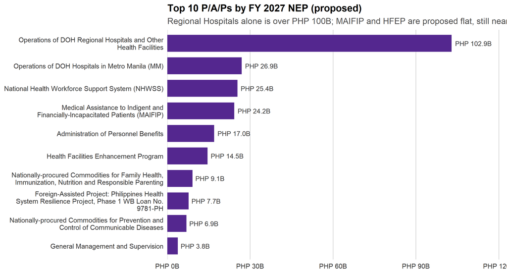

```r
top_pap <- pap_year %>% filter(year == 2027) %>% arrange(desc(NEP)) %>% slice_head(n = 10) %>%
  mutate(pap = factor(pap, levels = rev(pap)))

ggplot(top_pap, aes(pap, NEP)) +
  geom_col(fill = "#54278F", width = 0.75) +
  geom_text(aes(label = php_b(NEP)), hjust = -0.1, size = 3.3, color = "grey20") +
  coord_flip() +
  scale_x_discrete(labels = function(x) str_wrap(x, 50)) +
  scale_y_continuous(labels = php_b_axis, expand = expansion(mult = c(0, .18))) +
  labs(title = "Top 10 P/A/Ps by FY 2027 NEP (proposed)",
       subtitle = "Regional Hospitals alone is over PHP 100B; MAIFIP and HFEP are proposed flat, still near the top",
       x = NULL, y = NULL) +
  theme_doh() +
  theme(panel.grid.major.y = element_blank(), panel.grid.major.x = element_line(color = "grey85"))
```

### The FY 2027 proposal in context: every P/A/P (interactive)

Every P/A/P, ranked by the FY 2027 proposal (NEP), shown against the FY 2026 proposal and enacted budget, with each line’s FY 2025 cash-execution rate (D/A). Sort, search, or export.

```r
ref_2027 <- pap_year %>% filter(year == 2027) %>%
  transmute(`P/A/P` = pap, `NEP 2027 (B)` = NEP/1e9)
nep_gaa_26 <- pap_year %>% filter(year == 2026) %>%
  transmute(`P/A/P` = pap, `NEP 2026 (B)` = NEP/1e9, `GAA 2026 (B)` = GAA/1e9)
da_25 <- pap_year %>% filter(year == 2025) %>%
  transmute(`P/A/P` = pap, `D/A 2025` = Disbursements / AdjAllot)
ref_2027 <- ref_2027 %>%
  left_join(nep_gaa_26, by = "P/A/P") %>% left_join(da_25, by = "P/A/P") %>%
  arrange(desc(`NEP 2027 (B)`))
dt_table(ref_2027, page = 15,
         money_cols = c("NEP 2027 (B)","NEP 2026 (B)","GAA 2026 (B)"),
         pct_cols = c("D/A 2025"))
```

| P/A/P | NEP 2027 (B) | NEP 2026 (B) | GAA 2026 (B) | D/A 2025 |
| --- | --- | --- | --- | --- |
| Operations of DOH Regional Hospitals and Other Health Facilities | 102.867031 | 95.259437 | 101.749437 | 0.8676342037791657 |
| Operations of DOH Hospitals in Metro Manila (MM) | 26.929375 | 26.468492 | 29.980564 | 0.8592120667240349 |
| National Health Workforce Support System (NHWSS) | 25.394542 | 23.356518 | 23.356518 | 0.9516713234458266 |
| Medical Assistance to Indigent and Financially-Incapacitated Patients (MAIFIP) | 24.238078 | 24.237564 | 51.647816 | 0.6134897613551633 |
| Administration of Personnel Benefits | 16.980454 | 14.2791 | 14.2791 | 0.9731408730401592 |
| Health Facilities Enhancement Program | 14.539832 | 14.538644 | 22.294967 | 0.2236508567853659 |
| Nationally-procured Commodities for Family Health, Immunization, Nutrition and Responsible Parenting | 9.095219 | 10.241198 | 10.241198 | 0.05657673413656229 |
| Foreign-Assisted Project: Philippines Health System Resilience Project, Phase 1 WB Loan No. 9781-PH | 7.72711 | 8.669531 | 8.669531 |  |
| Nationally-procured Commodities for Prevention and Control of Communicable Diseases | 6.892852 | 7.719625 | 7.719625 | 0.2145613985251589 |
| General Management and Supervision | 3.774291 | 3.818183 | 3.818183 | 0.8541301438222683 |

[output cut: 83 more lines]

## 5.4 What the FY 2027 proposal changes

Comparing the two *proposals* — the FY 2026 NEP against the FY 2027 NEP — isolates what the Executive itself chose to change, before Congress touches the budget. **MAIFIP and HFEP do not appear here at all**: both are proposed essentially flat (~₱24B and ~₱15B again), so any apparent “cut” in those lines exists only against the Congress-inflated 2026 GAA, not against the Executive’s own prior proposal.

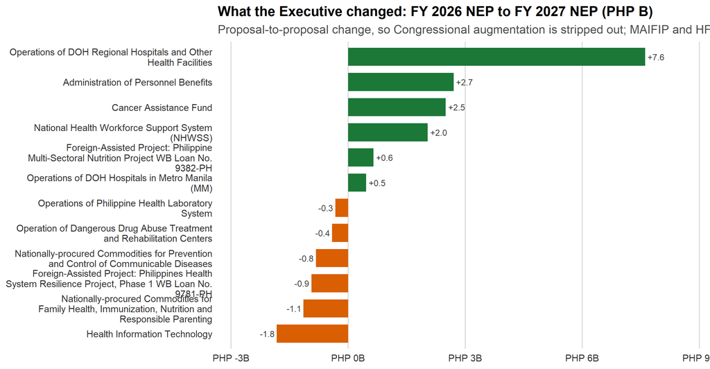

```r
nep_change <- pap_year %>%
  filter(year %in% c(2026, 2027)) %>%
  select(pap, year, NEP) %>%
  pivot_wider(names_from = year, values_from = NEP, names_prefix = "y") %>%
  mutate(change = (y2027 - y2026) / 1e9) %>%
  filter(!is.na(change), abs(change) >= 0.3)
ups   <- nep_change %>% filter(change > 0) %>% arrange(desc(change)) %>% slice_head(n = 8)
downs <- nep_change %>% filter(change < 0) %>% arrange(change)       %>% slice_head(n = 6)
nep_change <- bind_rows(ups, downs) %>% arrange(desc(change)) %>%
  mutate(pap = factor(pap, levels = rev(pap)),
         dir = ifelse(change >= 0, "Increased", "Reduced"))

ggplot(nep_change, aes(pap, change, fill = dir)) +
  geom_col(width = 0.72) +
  geom_text(aes(label = sprintf("%+.1f", change),
                hjust = ifelse(change >= 0, -0.15, 1.15)),
            size = 3, color = "grey25") +
  coord_flip() +
  scale_fill_manual(values = c("Increased" = "#1B7837", "Reduced" = "#D95F02")) +
  scale_x_discrete(labels = function(x) str_wrap(x, 46)) +
  scale_y_continuous(labels = function(x) paste0(peso, x, "B"),
                     expand = expansion(mult = c(0.16, 0.16))) +
  labs(title = "What the Executive changed: FY 2026 NEP to FY 2027 NEP (PHP B)",
       subtitle = "Proposal-to-proposal change, so Congressional augmentation is stripped out; MAIFIP and HFEP are proposed flat",
       x = NULL, y = NULL) +
  theme_doh() +
  theme(panel.grid.major.y = element_blank(),
        panel.grid.major.x = element_line(color = "grey85"),
        legend.position = "none")
```

The biggest single increase is **Regional Hospitals (+₱7.6B)**, consistent with a proposal that leans further into direct hospital operations; the **Cancer Assistance Fund triples** (from ₱1.25B to ₱3.75B), and the health workforce (NHWSS, +₱2.0B) and personnel benefits (+₱2.7B) also rise. The reductions are smaller and land on **health information technology (−₱1.8B)** and several **nationally-procured commodity** lines. Because MAIFIP and HFEP — the two lines Congress most reliably augments — are held flat in the proposal, the real FY 2027 budget for those programs will again be settled at enactment, not in the NEP.

# 6 Congressional action: NEP → GAA

Congress augments DOH year after year. The chart ranks the ten P/A/Ps that have received the most cumulative plus-ups (GAA above NEP) over 2018–2026.

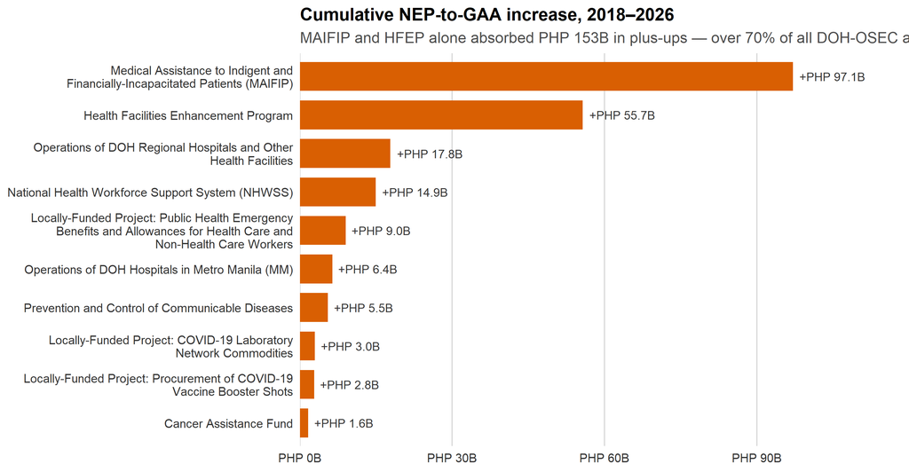

```r
top_aug <- pap_year %>% filter(year <= 2026) %>% group_by(pap) %>%
  summarise(total_nep = sum(NEP, na.rm = TRUE), total_gaa = sum(GAA, na.rm = TRUE), .groups = "drop") %>%
  mutate(augment = total_gaa - total_nep) %>% filter(augment > 0) %>%
  arrange(desc(augment)) %>% slice_head(n = 10) %>% mutate(pap = factor(pap, levels = rev(pap)))

ggplot(top_aug, aes(pap, augment)) +
  geom_col(fill = "#D95F02", width = 0.75) +
  geom_text(aes(label = paste0("+", php_b(augment))), hjust = -0.1, size = 3.3, color = "grey20") +
  coord_flip() +
  scale_x_discrete(labels = function(x) str_wrap(x, 50)) +
  scale_y_continuous(labels = php_b_axis, expand = expansion(mult = c(0, .22)), limits = c(0, NA)) +
  labs(title = "Cumulative NEP-to-GAA increase, 2018–2026",
       subtitle = "MAIFIP and HFEP alone absorbed PHP 153B in plus-ups — over 70% of all DOH-OSEC augmentation",
       x = NULL, y = NULL) +
  theme_doh() +
  theme(panel.grid.major.y = element_blank(), panel.grid.major.x = element_line(color = "grey85"))
```

Congress’s additions are strikingly concentrated. **MAIFIP** (₱97B cumulative) and **HFEP** (₱56B) together account for ₱153B — more than 70% of all DOH-OSEC augmentation since 2018. One is a cash-assistance (MOOE) line that disburses moderately; the other is a construction (capital-outlay) line that barely disburses at all. The legislature’s two favorite programs to fund are, respectively, the agency’s largest discretionary transfer and its deepest execution bottleneck.

The full cumulative table lists every P/A/P that Congress net-augmented over the nine years.

```r
aug_full <- pap_year %>% filter(year <= 2026) %>% group_by(pap) %>%
  summarise(nep = sum(NEP, na.rm = TRUE), gaa = sum(GAA, na.rm = TRUE), .groups = "drop") %>%
  mutate(aug = gaa - nep) %>% filter(abs(aug) >= 1e8) %>%
  transmute(`P/A/P` = pap, `Σ NEP 2018–26 (B)` = nep/1e9, `Σ GAA 2018–26 (B)` = gaa/1e9,
            `Cumulative augmentation (B)` = aug/1e9) %>%
  arrange(desc(`Cumulative augmentation (B)`))
dt_table(aug_full, page = 10,
         money_cols = c("Σ NEP 2018–26 (B)","Σ GAA 2018–26 (B)","Cumulative augmentation (B)"))
```

| P/A/P | Σ NEP 2018–26 (B) | Σ GAA 2018–26 (B) | Cumulative augmentation (B) |
| --- | --- | --- | --- |
| Medical Assistance to Indigent and Financially-Incapacitated Patients (MAIFIP) | 149.5237 | 246.637417 | 97.113717 |
| Health Facilities Enhancement Program | 142.82312 | 198.531809 | 55.708689 |
| Operations of DOH Regional Hospitals and Other Health Facilities | 402.117439 | 419.929052 | 17.811613 |
| National Health Workforce Support System (NHWSS) | 123.065025 | 137.975365 | 14.91034 |
| Locally-Funded Project: Public Health Emergency Benefits and Allowances for Health Care and Non-Health Care Workers | 39.924344 | 48.924344 | 9 |
| Operations of DOH Hospitals in Metro Manila (MM) | 134.523322 | 140.899724 | 6.376402 |
| Prevention and Control of Communicable Diseases | 24.739562 | 30.265412 | 5.52585 |
| Locally-Funded Project: COVID-19 Laboratory Network Commodities | 5.091994 | 8.045904 | 2.95391 |
| Locally-Funded Project: Procurement of COVID-19 Vaccine Booster Shots | 0 | 2.79297 | 2.79297 |
| Cancer Assistance Fund | 3.5 | 5.1492 | 1.6492 |

[output cut: 32 more lines]

## 6.1 Where the augmentation lands, by expense class

Congress’s fiscal preference is operating-expense-heavy. Splitting the cumulative plus-up by expense class shows it goes overwhelmingly to MOOE — commodities, cash-assistance lines, and contracted services — rather than to salaries or infrastructure.

```r
aug_ec <- df_long_all %>%
  filter(metric %in% c("NEP","GAA"), year <= 2026, expense_class %in% c("1PS","2MOOE","6CO")) %>%
  group_by(metric, expense_class) %>% summarise(a = sum(amount, na.rm = TRUE), .groups = "drop") %>%
  pivot_wider(names_from = metric, values_from = a) %>%
  transmute(`Expense class` = factor(expense_class, levels = c("1PS","2MOOE","6CO"), labels = ec_levels),
            `Σ NEP 2018–26 (B)` = round(NEP/1e9,1),
            `Σ GAA 2018–26 (B)` = round(GAA/1e9,1),
            `Cumulative augmentation (B)` = round((GAA-NEP)/1e9,1)) %>% arrange(`Expense class`)
kbl_clean(aug_ec, font = 13, align = "lrrr", na = "")
```

| Expense class | Σ NEP 2018–26 (B) | Σ GAA 2018–26 (B) | Cumulative augmentation (B) |
| --- | --- | --- | --- |
| Personnel Services (PS) | 577.7 | 594.7 | 17.0 |
| Maintenance & Other Op. Exp. (MOOE) | 658.9 | 784.1 | 125.2 |
| Capital Outlays (CO) | 175.5 | 243.9 | 68.4 |

# 7 MAIFIP: a flagship that exploded

Medical Assistance to Indigent and Financially-Incapacitated Patients is the single most consequential line in the DOH-OSEC budget’s recent history. It pays hospital bills for poor patients, and it has grown explosively — almost entirely on the strength of Congressional plus-ups.

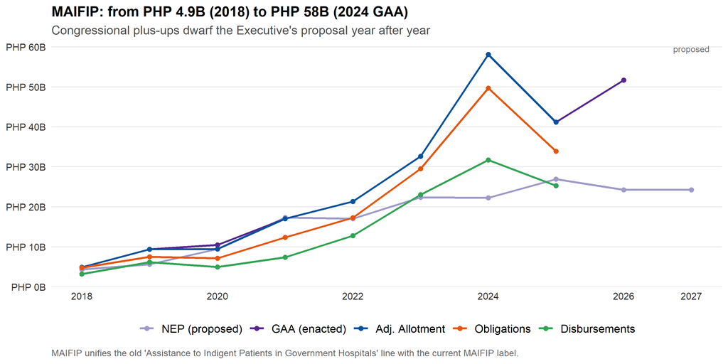

```r
maifip <- pap_year %>% filter(pap == MAIFIP_LAB) %>%
  select(year, NEP, GAA, AdjAllot, Obligations, Disbursements) %>%
  pivot_longer(-year, names_to = "metric", values_to = "amount") %>%
  mutate(metric = factor(metric, levels = c("NEP","GAA","AdjAllot","Obligations","Disbursements"),
                         labels = c("NEP (proposed)","GAA (enacted)","Adj. Allotment","Obligations","Disbursements")))

ggplot(maifip, aes(year, amount, color = metric, group = metric)) +
  geom_line(linewidth = 0.9) + geom_point(size = 1.8) +
  scale_color_manual(values = exec_pal) +
  scale_y_continuous(labels = php_b_axis, breaks = pretty_breaks(6),
                     limits = c(0, NA), expand = expansion(mult = c(0, .05))) +
  scale_x_continuous(breaks = c(seq(2018, 2026, 2), 2027)) +
  annotate("text", x = 2027, y = Inf, label = "proposed", vjust = 1.4, size = 3, color = "grey45") +
  labs(title = "MAIFIP: from PHP 4.9B (2018) to PHP 58B (2024 GAA)",
       subtitle = "Congressional plus-ups dwarf the Executive's proposal year after year",
       x = NULL, y = NULL,
       caption = "MAIFIP unifies the old 'Assistance to Indigent Patients in Government Hospitals' line with the current MAIFIP label.") +
  theme_doh() + guides(color = guide_legend(nrow = 1))
```

**In the FY 2027 proposal the Executive again proposes ₱24.2B for MAIFIP — essentially identical to its FY 2026 proposal**, and roughly the figure it has put forward for three years running. If the established pattern holds, Congress will again roughly double it at enactment. Reading the ₱24.2B proposal as a *cut* against the ₱51.7B FY 2026 GAA would be a proposal-versus-enacted error: the Executive is not shrinking MAIFIP, it is under-proposing a line it fully expects Congress to restore. That keeps the annual restoration a live advocacy question rather than a foregone conclusion — and sharpens the deeper one of whether MAIFIP is functioning as a de facto substitute for PhilHealth case-rate coverage or as a discretionary assistance line.

```r
pap_year %>% filter(pap == MAIFIP_LAB, year %in% 2018:2025) %>%
  transmute(FY = year, `NEP (B)` = round(NEP/1e9,1), `GAA (B)` = round(GAA/1e9,1),
            `Allotment (B)` = round(AdjAllot/1e9,1), `Obligated (B)` = round(Obligations/1e9,1),
            `Disbursed (B)` = round(Disbursements/1e9,1),
            `O/A` = scales::percent(Obligations/AdjAllot, accuracy = 1),
            `D/A` = scales::percent(Disbursements/AdjAllot, accuracy = 1)) %>%
  kbl_clean(font = 13, align = "rrrrrrrr", na = "")
```

| FY | NEP (B) | GAA (B) | Allotment (B) | Obligated (B) | Disbursed (B) | O/A | D/A |
| --- | --- | --- | --- | --- | --- | --- | --- |
| 2018 | 4.3 | 4.9 | 4.9 | 4.8 | 3.2 | 98% | 66% |
| 2019 | 5.6 | 9.4 | 9.4 | 7.5 | 6.2 | 80% | 66% |
| 2020 | 9.4 | 10.5 | 9.4 | 7.2 | 4.9 | 76% | 52% |
| 2021 | 17.3 | 17.0 | 17.0 | 12.4 | 7.4 | 73% | 43% |
| 2022 | 17.0 | 21.4 | 21.4 | 17.3 | 12.8 | 81% | 60% |
| 2023 | 22.4 | 32.6 | 32.6 | 29.5 | 23.0 | 90% | 71% |
| 2024 | 22.3 | 58.1 | 58.1 | 49.6 | 31.7 | 85% | 55% |
| 2025 | 26.9 | 41.2 | 41.2 | 33.9 | 25.3 | 82% | 61% |

In 2024 MAIFIP obligated ₱49.6B of its ₱58.1B allotment (85%) but disbursed only ₱31.7B (55%). Even in 2018, on a far smaller ₱4.9B base, it disbursed only about two-thirds. The open question is what MAIFIP *is*: a de facto substitute for PhilHealth case-rate coverage, or a discretionary assistance line whose size is set politically rather than by demand. The persistent proposal-versus-enacted gap is consistent with the latter dynamic.

# 8 Absorptive capacity

## 8.1 At the aggregate

At the whole-office level, obligation rates hold near 90% while disbursement rates have climbed from 53% (2018) to about 70% in recent years — an improving but still incomplete conversion of releases into cash.

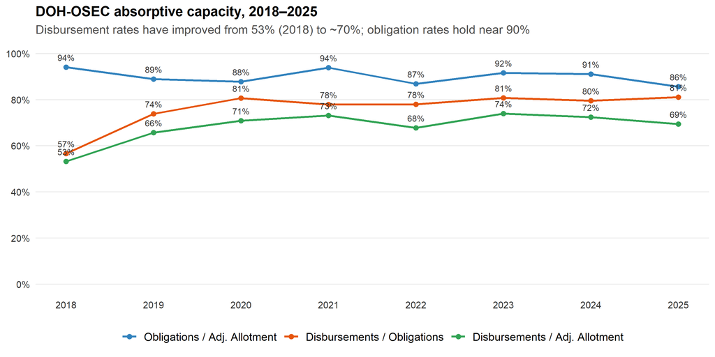

```r
absorp_long <- absorp_total %>% select(year, oblig_allot, disb_oblig, disb_allot) %>%
  pivot_longer(-year, names_to = "ratio", values_to = "value") %>%
  mutate(ratio = factor(ratio, levels = c("oblig_allot","disb_oblig","disb_allot"),
    labels = c("Obligations / Adj. Allotment","Disbursements / Obligations","Disbursements / Adj. Allotment")))

ggplot(absorp_long, aes(year, value, color = ratio, group = ratio)) +
  geom_line(linewidth = 0.9) + geom_point(size = 2) +
  geom_text(aes(label = scales::percent(value, accuracy = 1)), vjust = -1.0, size = 3.0, show.legend = FALSE, color = "grey20") +
  scale_color_manual(values = absorp_pal) +
  scale_y_continuous(labels = percent_format(accuracy = 1), limits = c(0, 1.0), breaks = seq(0, 1, 0.2)) +
  scale_x_continuous(breaks = 2018:2025) +
  labs(title = "DOH-OSEC absorptive capacity, 2018–2025",
       subtitle = "Disbursement rates have improved from 53% (2018) to ~70%; obligation rates hold near 90%",
       x = NULL, y = NULL) +
  theme_doh() + guides(color = guide_legend(nrow = 1))
```

```r
absorp_total %>%
  transmute(Year = year, `Allotment (B)` = round(AdjAllot/1e9,1),
            `Obligations (B)` = round(Obligations/1e9,1), `Disbursements (B)` = round(Disbursements/1e9,1),
            `O/A` = scales::percent(oblig_allot, accuracy = 1),
            `D/O` = scales::percent(disb_oblig, accuracy = 1),
            `D/A` = scales::percent(disb_allot, accuracy = 1)) %>%
  kbl_clean(font = 13, align = "rrrrrrr", na = "")
```

| Year | Allotment (B) | Obligations (B) | Disbursements (B) | O/A | D/O | D/A |
| --- | --- | --- | --- | --- | --- | --- |
| 2018 | 102.9 | 96.7 | 54.8 | 94% | 57% | 53% |
| 2019 | 93.1 | 82.9 | 61.2 | 89% | 74% | 66% |
| 2020 | 98.7 | 86.7 | 70.0 | 88% | 81% | 71% |
| 2021 | 134.5 | 126.3 | 98.4 | 94% | 78% | 73% |
| 2022 | 180.6 | 156.9 | 122.4 | 87% | 78% | 68% |
| 2023 | 208.8 | 191.4 | 154.6 | 92% | 81% | 74% |
| 2024 | 230.5 | 209.9 | 167.0 | 91% | 80% | 72% |
| 2025 | 225.3 | 192.9 | 156.5 | 86% | 81% | 69% |

## 8.2 By expense class

Decomposing the aggregate by expense class locates the problem precisely.

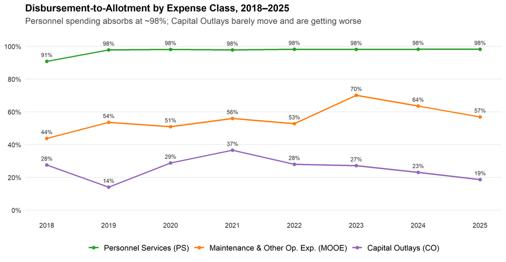

```r
absorp_ec <- df_long_all %>%
  filter(metric %in% c("AdjAllot","Disbursements"), expense_class %in% c("1PS","2MOOE","6CO"), year %in% 2018:2025) %>%
  group_by(year, metric, expense_class) %>% summarise(amount = sum(amount, na.rm = TRUE), .groups = "drop") %>%
  pivot_wider(names_from = metric, values_from = amount) %>%
  mutate(da = ifelse(AdjAllot > 0, Disbursements/AdjAllot, NA_real_),
         expense_class = factor(expense_class, levels = c("1PS","2MOOE","6CO"), labels = ec_levels))

ggplot(absorp_ec, aes(year, da, color = expense_class, group = expense_class)) +
  geom_line(linewidth = 0.9) + geom_point(size = 1.8) +
  geom_text(aes(label = scales::percent(da, accuracy = 1)), vjust = -1.0, size = 2.9, show.legend = FALSE, color = "grey20") +
  scale_color_manual(values = ec_pal) +
  scale_y_continuous(labels = percent_format(accuracy = 1), limits = c(0, 1.05), breaks = seq(0, 1, 0.2)) +
  scale_x_continuous(breaks = 2018:2025) +
  labs(title = "Disbursement-to-Allotment by Expense Class, 2018–2025",
       subtitle = "Personnel spending absorbs at ~98%; Capital Outlays barely move and are getting worse",
       x = NULL, y = NULL) +
  theme_doh() + guides(color = guide_legend(nrow = 1))
```

```r
absorp_ec %>% mutate(da = round(da*100,0)) %>% select(expense_class, year, da) %>%
  pivot_wider(names_from = year, values_from = da) %>%
  rename(`D/A by expense class (%)` = expense_class) %>% kbl_clean(font = 12.5, na = "")
```

| D/A by expense class (%) | 2018 | 2019 | 2020 | 2021 | 2022 | 2023 | 2024 | 2025 |
| --- | --- | --- | --- | --- | --- | --- | --- | --- |
| Personnel Services (PS) | 91 | 98 | 98 | 98 | 98 | 98 | 98 | 98 |
| Maintenance & Other Op. Exp. (MOOE) | 44 | 54 | 51 | 56 | 53 | 70 | 64 | 57 |
| Capital Outlays (CO) | 28 | 14 | 29 | 37 | 28 | 27 | 23 | 19 |

## 8.3 Strongest and weakest absorbers (FY 2025)

The strongest absorbers are personnel-type and recurring-operations lines; the weakest are capital-heavy or newly-created lines. Both tables cover P/A/Ps with a 2025 allotment of at least ₱0.5B.

```r
abs_2025 <- pap_year %>% filter(year == 2025, !is.na(AdjAllot), AdjAllot >= 5e8) %>%
  mutate(`O/A` = Obligations/AdjAllot, `D/A` = Disbursements/AdjAllot, `Allotment (B)` = round(AdjAllot/1e9, 2))
```

**Strongest absorbers, FY 2025** — ranked by obligation rate. Salary-type and hospital-operations lines obligate up front and disburse cleanly.

```r
abs_2025 %>% arrange(desc(`O/A`)) %>% slice_head(n = 10) %>%
  transmute(`P/A/P` = str_trunc(pap, 54), `Allotment (B)`,
            `O/A` = scales::percent(`O/A`, accuracy = 1), `D/A` = scales::percent(`D/A`, accuracy = 1)) %>%
  kbl_clean(font = 13, align = "lrrr", na = "")
```

| P/A/P | Allotment (B) | O/A | D/A |
| --- | --- | --- | --- |
| Administration of Personnel Benefits | 11.95 | 100% | 97% |
| Regulation of Health Establishments and Products | 0.50 | 100% | 99% |
| National Health Workforce Support System (NHWSS) | 17.92 | 100% | 95% |
| Operation of Dangerous Drug Abuse Treatment and Reh… | 1.76 | 99% | 95% |
| Cancer Assistance Fund | 1.25 | 99% | 92% |
| Operations of DOH Hospitals in Metro Manila (MM) | 21.91 | 99% | 86% |
| Operations of DOH Regional Hospitals and Other Heal… | 73.71 | 97% | 87% |
| Foreign-Assisted Project: Philippine Multi-Sectoral… | 1.44 | 97% | 96% |
| Local Health Systems Development and Assistance | 0.66 | 94% | 76% |
| Operations of Blood Centers and National Voluntary … | 0.65 | 93% | 45% |

**Weakest absorbers, FY 2025** — ranked by disbursement rate. The new (2025) commodities lines under `3502` came in near-zero in their first year; HFEP and the Quick Response Fund are perennial.

```r
abs_2025 %>% arrange(`D/A`) %>% slice_head(n = 10) %>%
  transmute(`P/A/P` = str_trunc(pap, 54), `Allotment (B)`,
            `O/A` = scales::percent(`O/A`, accuracy = 1), `D/A` = scales::percent(`D/A`, accuracy = 1)) %>%
  kbl_clean(font = 13, align = "lrrr", na = "")
```

| P/A/P | Allotment (B) | O/A | D/A |
| --- | --- | --- | --- |
| Nationally-procured Commodities for Family Planning… | 0.75 | 0% | 0% |
| Nationally-procured Commodities for Prevention and … | 3.48 | 13% | 0% |
| Nationally-procured Commodities for Family Health, … | 10.18 | 56% | 6% |
| Quick Response Fund | 0.50 | 50% | 6% |
| Health Information Technology | 2.30 | 10% | 8% |
| Nationally-procured Commodities for Prevention and … | 5.14 | 31% | 21% |
| Health Facilities Enhancement Program | 16.61 | 62% | 22% |
| Operations of Philippine Health Laboratory System | 0.75 | 60% | 26% |
| Supply Chain Management | 0.90 | 76% | 38% |
| Operations of Blood Centers and National Voluntary … | 0.65 | 93% | 45% |

The weakest-absorber list mixes a genuine structural problem with a likely transition artefact. **HFEP** disbursing only 22% of a ₱16.6B allotment is consistent with its long-running implementation lag. But three of the **new commodities programs** under PREXC `3502` disbursing near-zero in 2025 may reflect the coding transition rather than a real procurement failure — first-year lines often look catastrophic before they settle. The **Quick Response Fund** disbursing 6% of its ₱500M ceiling is, by contrast, a recurring story: emergency money that rarely flows on schedule.

### Full absorption table, FY 2025 (interactive)

Every P/A/P with a 2025 allotment, all three ratios, sortable and searchable.

```r
abs_full <- pap_year %>% filter(year == 2025, !is.na(AdjAllot), AdjAllot > 0) %>%
  transmute(`P/A/P` = pap, `Allotment (B)` = AdjAllot/1e9, `Obligations (B)` = Obligations/1e9,
            `Disbursements (B)` = Disbursements/1e9, `O/A` = Obligations/AdjAllot,
            `D/O` = ifelse(Obligations>0, Disbursements/Obligations, NA_real_), `D/A` = Disbursements/AdjAllot) %>%
  arrange(`D/A`)
dt_table(abs_full, page = 15,
         money_cols = c("Allotment (B)","Obligations (B)","Disbursements (B)"),
         pct_cols = c("O/A","D/O","D/A"))
```

| P/A/P | Allotment (B) | Obligations (B) | Disbursements (B) | O/A | D/O | D/A |
| --- | --- | --- | --- | --- | --- | --- |
| Nationally-procured Commodities for Family Planning and Reproductive Health | 0.749919 | 0 | 0 | 0 |  | 0 |
| Nationally-procured Commodities for Prevention and Control of Non-Communicable Diseases | 3.47724 | 0.45851785851 | 0.01312770729 | 0.1318625859906132 | 0.02863074370245863 | 0.00377532390344066 |
| Nationally-procured Commodities for Family Health, Immunization, Nutrition and Responsible Parenting | 10.178169 | 5.73821779841 | 0.5758475615099999 | 0.5637770210349229 | 0.1003530332483304 | 0.05657673413656229 |
| Quick Response Fund | 0.5 | 0.24831111121 | 0.02862956363 | 0.49662222242 | 0.1152971507818979 | 0.05725912726 |
| Health Information Technology | 2.300992 | 0.22854032481 | 0.17960294056 | 0.09932252037816733 | 0.7858698052928527 | 0.07805456975078574 |
| Corporate Communications | 0.087 | 0.03589190945 | 0.01262084502 | 0.4125506833333334 | 0.3516348172443079 | 0.145067184137931 |
| Nationally-procured Commodities for Prevention and Control of Communicable Diseases | 5.143876 | 1.61749133579 | 1.1036772284 | 0.3144499081606944 | 0.6823388811915659 | 0.2145613985251589 |
| Health Facilities Enhancement Program | 16.610998 | 10.31684795949 | 3.71506393476 | 0.6210853772596926 | 0.3600967998508383 | 0.2236508567853659 |
| Human Resources for Health (HRH) and Institutional Capacity Management | 0.462598 | 0.30073148557 | 0.11776522661 | 0.6500924897427139 | 0.3915959327863204 | 0.2545735749181795 |
| Operations of Philippine Health Laboratory System | 0.745254 | 0.44960287982 | 0.19106135541 | 0.6032881136095881 | 0.4249558087494725 | 0.2563707882279062 |

[output cut: 32 more lines]

# 9 Program deep-dives

## 9.1 Trajectories of the largest health programs

Six heavyweight programs, each showing enacted budget, allotment, and disbursements together. Where the lines sit on top of one another, execution is clean; where disbursements fall away, money is released but unspent.

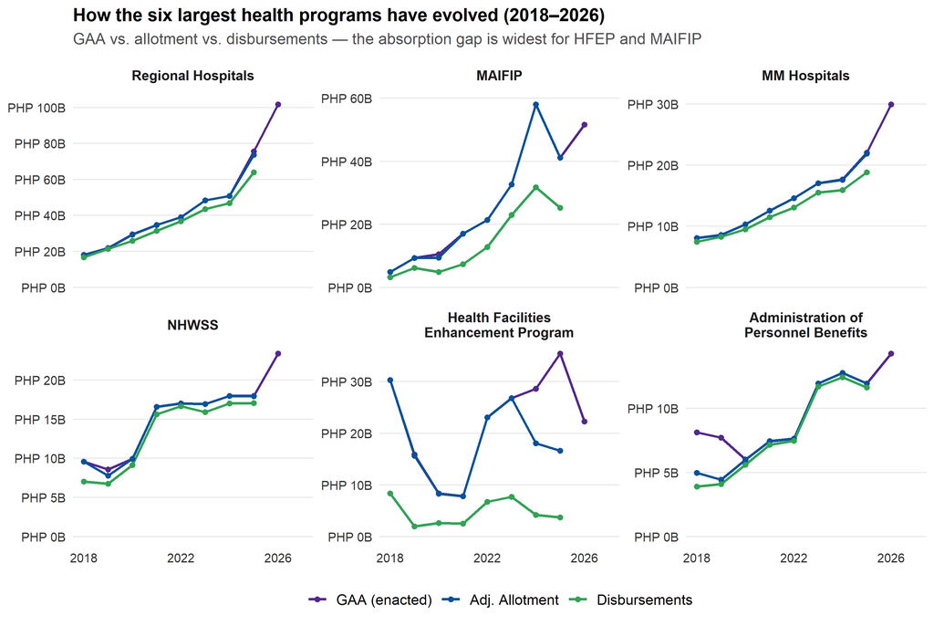

```r
trend_paps <- c(
  "Operations of DOH Regional Hospitals and Other Health Facilities",
  MAIFIP_LAB,
  "Operations of DOH Hospitals in Metro Manila (MM)",
  "National Health Workforce Support System (NHWSS)",
  "Health Facilities Enhancement Program",
  "Administration of Personnel Benefits")

trend_dat <- pap_year %>% filter(pap %in% trend_paps) %>%
  select(pap, year, GAA, AdjAllot, Disbursements) %>%
  pivot_longer(c(GAA, AdjAllot, Disbursements), names_to = "metric", values_to = "amount") %>%
  mutate(metric = factor(metric, levels = c("GAA","AdjAllot","Disbursements"),
                         labels = c("GAA (enacted)","Adj. Allotment","Disbursements")),
         pap = factor(pap, levels = trend_paps,
                      labels = c("Regional Hospitals","MAIFIP","MM Hospitals","NHWSS",
                                 "Health Facilities Enhancement Program","Administration of Personnel Benefits")))
trend_pal <- c("GAA (enacted)" = "#54278F","Adj. Allotment" = "#08519C","Disbursements" = "#31A354")

ggplot(trend_dat, aes(year, amount, color = metric, group = metric)) +
  geom_line(linewidth = 0.9) + geom_point(size = 1.5) +
  facet_wrap(~ pap, ncol = 3, scales = "free_y",
             labeller = label_wrap_gen(width = 24)) + expand_limits(y = 0) +
  scale_color_manual(values = trend_pal) +
  scale_y_continuous(labels = php_b_axis, breaks = pretty_breaks(4)) +
  scale_x_continuous(breaks = c(2018, 2022, 2026)) +
  labs(title = "How the six largest health programs have evolved (2018–2026)",
       subtitle = "GAA vs. allotment vs. disbursements — the absorption gap is widest for HFEP and MAIFIP",
       x = NULL, y = NULL) +
  theme_doh() + guides(color = guide_legend(nrow = 1))
```

## 9.2 Zooming in on HFEP

The Health Facilities Enhancement Program — DOH-OSEC’s main infrastructure line — is the deepest structural absorption issue in the portfolio. It builds and upgrades health facilities, and it has never managed to spend what it is given.

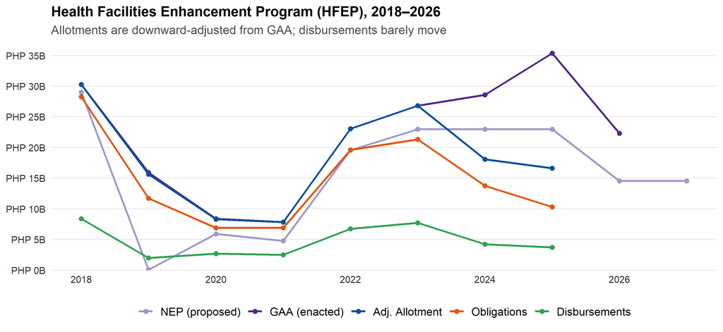

```r
hfep <- pap_year %>% filter(pap == "Health Facilities Enhancement Program") %>%
  select(year, NEP, GAA, AdjAllot, Obligations, Disbursements) %>%
  pivot_longer(-year, names_to = "metric", values_to = "amount") %>%
  mutate(metric = factor(metric, levels = c("NEP","GAA","AdjAllot","Obligations","Disbursements"),
                         labels = c("NEP (proposed)","GAA (enacted)","Adj. Allotment","Obligations","Disbursements")))

ggplot(hfep, aes(year, amount, color = metric, group = metric)) +
  geom_line(linewidth = 0.9) + geom_point(size = 1.8) +
  scale_color_manual(values = exec_pal) +
  scale_y_continuous(labels = php_b_axis, breaks = pretty_breaks(6), limits = c(0, NA), expand = expansion(mult = c(0, .05))) +
  scale_x_continuous(breaks = seq(2018, 2026, 2)) +
  labs(title = "Health Facilities Enhancement Program (HFEP), 2018–2026",
       subtitle = "Allotments are downward-adjusted from GAA; disbursements barely move",
       x = NULL, y = NULL) +
  theme_doh() + guides(color = guide_legend(nrow = 1))
```

```r
pap_year %>% filter(pap == "Health Facilities Enhancement Program", year %in% 2018:2025) %>%
  transmute(FY = year, `NEP (B)` = round(NEP/1e9,1), `GAA (B)` = round(GAA/1e9,1),
            `Allotment (B)` = round(AdjAllot/1e9,1), `Disbursed (B)` = round(Disbursements/1e9,1),
            `D/A` = scales::percent(Disbursements/AdjAllot, accuracy = 1)) %>%
  kbl_clean(font = 14, align = "rrrrrr", na = "")
```

| FY | NEP (B) | GAA (B) | Allotment (B) | Disbursed (B) | D/A |
| --- | --- | --- | --- | --- | --- |
| 2018 | 29.0 | 30.3 | 30.3 | 8.4 | 28% |
| 2019 | 0.0 | 15.9 | 15.6 | 2.0 | 13% |
| 2020 | 5.9 | 8.4 | 8.3 | 2.7 | 32% |
| 2021 | 4.8 | 7.8 | 7.8 | 2.5 | 32% |
| 2022 | 19.6 | 23.1 | 23.1 | 6.7 | 29% |
| 2023 | 23.0 | 26.8 | 26.8 | 7.7 | 29% |
| 2024 | 23.0 | 28.6 | 18.1 | 4.2 | 23% |
| 2025 | 23.0 | 35.4 | 16.6 | 3.7 | 22% |

## 9.3 Chronic low absorbers

A set of public-health programs with persistently low obligation rates. Several lines stop in 2024 because the 2025 reorganization re-coded them (`3103` → `3501`/`3502`), which is itself part of the story — reorganizations interrupt execution histories.

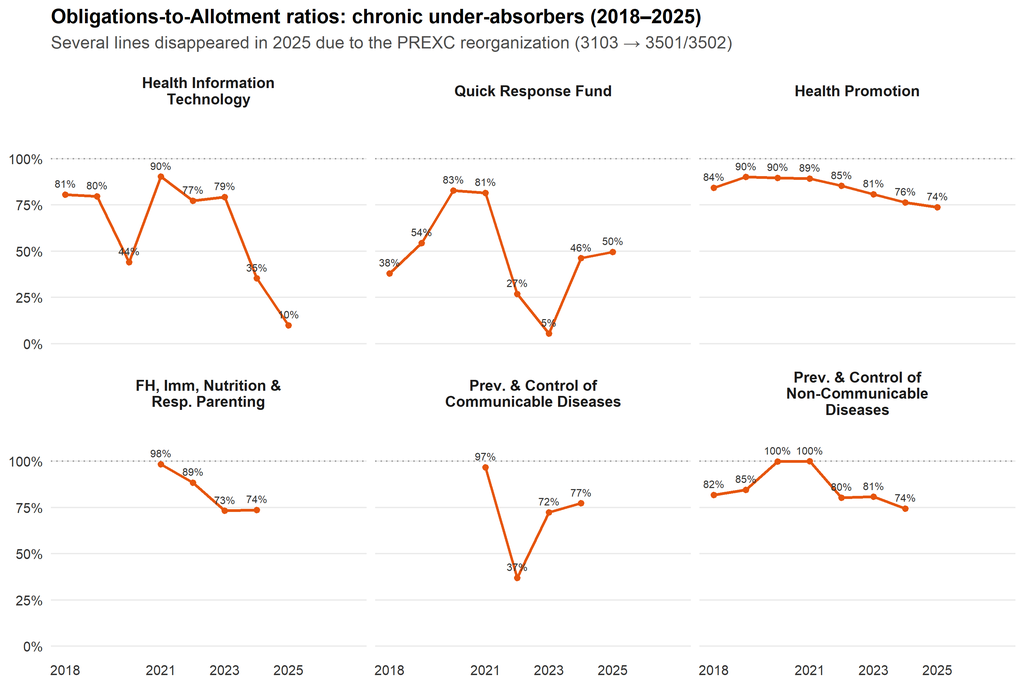

```r
low_paps <- c("Health Information Technology","Quick Response Fund","Health Promotion",
              "Family Health, Immunization, Nutrition and Responsible Parenting",
              "Prevention and Control of Communicable Diseases","Prevention and Control of Non-Communicable Diseases")

low_dat <- pap_year %>% filter(pap %in% low_paps) %>%
  mutate(oa = ifelse(!is.na(AdjAllot) & AdjAllot > 0, Obligations/AdjAllot, NA_real_),
         pap = factor(pap, levels = low_paps,
                      labels = c("Health Information Technology","Quick Response Fund","Health Promotion",
                                 "FH, Imm, Nutrition & Resp. Parenting","Prev. & Control of Communicable Diseases",
                                 "Prev. & Control of Non-Communicable Diseases"))) %>%
  select(pap, year, oa) %>% tidyr::complete(year = 2018:2025, pap)

ggplot(low_dat, aes(year, oa, group = 1)) +
  geom_hline(yintercept = 1, linetype = "dotted", color = "grey60") +
  geom_line(linewidth = 0.9, color = "#E6550D") + geom_point(size = 1.6, color = "#E6550D") +
  geom_text(aes(label = scales::percent(oa, accuracy = 1)), vjust = -0.9, size = 2.6, color = "grey20") +
  facet_wrap(~ pap, ncol = 3, labeller = label_wrap_gen(width = 24)) +
  scale_y_continuous(labels = percent_format(accuracy = 1), limits = c(0, 1.15), breaks = seq(0, 1, 0.25)) +
  scale_x_continuous(breaks = c(2018, 2021, 2023, 2025)) +
  labs(title = "Obligations-to-Allotment ratios: chronic under-absorbers (2018–2025)",
       subtitle = "Several lines disappeared in 2025 due to the PREXC reorganization (3103 → 3501/3502)",
       x = NULL, y = NULL) +
  theme_doh() + theme(legend.position = "none")
```

These are the public-health and emergency-response lines — health promotion, disease control, the Quick Response Fund, health IT — where even the *obligation* rate (a looser test than disbursement) runs well below full. They are individually small but collectively define the agency’s public-health-delivery capacity, and they are precisely the programs the 2025 reorganization was meant to rationalize.

# 10 Line-item reference

The top 30 P/A/Ps by 2026 GAA, with the 2026 NEP and GAA, the prior-year (2025) enacted budget, and the most recent (2025) disbursement-to-allotment ratio as an execution indicator. The full unabridged list is in the ranking section above.

```r
ref <- pap_year %>% filter(year == 2026, !is.na(GAA), GAA > 0) %>%
  arrange(desc(GAA)) %>% slice_head(n = 30) %>%
  transmute(pap, `NEP 2026 (B)` = NEP/1e9, `GAA 2026 (B)` = GAA/1e9)
ctx_2025 <- pap_year %>% filter(year == 2025) %>%
  transmute(pap, `GAA 2025 (B)` = GAA/1e9,
            `D/A 2025` = ifelse(!is.na(AdjAllot) & AdjAllot > 0, Disbursements/AdjAllot, NA_real_))
ref %>% left_join(ctx_2025, by = "pap") %>% rename(`P/A/P` = pap) %>%
  dt_table(page = 15, money_cols = c("NEP 2026 (B)","GAA 2026 (B)","GAA 2025 (B)"), pct_cols = "D/A 2025")
```

| P/A/P | NEP 2026 (B) | GAA 2026 (B) | GAA 2025 (B) | D/A 2025 |
| --- | --- | --- | --- | --- |
| Operations of DOH Regional Hospitals and Other Health Facilities | 95.259437 | 101.749437 | 75.60683 | 0.8676342037791657 |
| Medical Assistance to Indigent and Financially-Incapacitated Patients (MAIFIP) | 24.237564 | 51.647816 | 41.15991 | 0.6134897613551633 |
| Operations of DOH Hospitals in Metro Manila (MM) | 26.468492 | 29.980564 | 22.065476 | 0.8592120667240349 |
| National Health Workforce Support System (NHWSS) | 23.356518 | 23.356518 | 17.97108 | 0.9516713234458266 |
| Health Facilities Enhancement Program | 14.538644 | 22.294967 | 35.367037 | 0.2236508567853659 |
| Administration of Personnel Benefits | 14.2791 | 14.2791 | 11.95848 | 0.9731408730401592 |
| Nationally-procured Commodities for Family Health, Immunization, Nutrition and Responsible Parenting | 10.241198 | 10.241198 | 10.178289 | 0.05657673413656229 |
| Foreign-Assisted Project: Philippines Health System Resilience Project, Phase 1 WB Loan No. 9781-PH | 8.669531 | 8.669531 |  |  |
| Nationally-procured Commodities for Prevention and Control of Communicable Diseases | 7.719625 | 7.719625 | 5.37572 | 0.2145613985251589 |
| General Management and Supervision | 3.818183 | 3.818183 | 2.485134 | 0.8541301438222683 |

[output cut: 20 more lines]

2026 execution data is not yet available; the 2025 D/A column indicates how each line has most recently absorbed.

# 11 Questions for discussion

1. **MAIFIP’s growth path.** If Congress keeps adding ₱20–35B in plus-ups annually, is the program institutionally ready to absorb and account for the increase — and what is the distributional incidence of the assistance?
2. **HFEP’s chronic absorption gap.** What would actually push disbursement past 50% — procurement reform, multi-year obligation authority, NGA–LGU coordination — and is the 2026 cut an admission that the capacity simply isn’t there?
3. **The 3501/3502 split.** Is separating commodities/local support from policy/strategy a useful reform, or does it create new coordination costs and first-year absorptive risk, as the near-zero 2025 commodities disbursement suggests?
4. **The Quick Response Fund.** Dead weight or genuine insurance? If the latter, what redesign would let it actually flow during emergencies rather than disbursing 6%?
5. **The rising operations share.** Is DOH-OSEC slowly becoming an agency that operates hospitals first and stewards the health system second — and is that the intended division of labor with PhilHealth and the LGUs?

Underlying data: DBM-published budget and execution data for the DOH Office of the Secretary (Current New Appropriations only), FY 2018–2026. Execution measures (Allotments, Obligations, Disbursements) cover FY 2018–2025. Prepared as the long-form companion to the DOH-OSEC budget briefing.